# Analysis of timing of MRCA & copy number gains

knitr document to capture the methods and R code for analysing chronological age at which landmark events occur during kidney cancer development.

## Mutation burden as a molecular clock

The analyses here are predicated on the assumption that total mutation burden in kidney cancer can act as a molecular clock. There are three major lines of evidence supporting this, discussed further in the main manuscript:

(1) Overall mutation burden in kidney cancer correlates linearly with age at diagnosis (explored further below);

(2) Mutation signatures in kidney cancer are mostly restricted to signatures 1 and 5, signatures that are nearly ubiquitous across tumour types and show a linear correlation with age (see [Alexandrov et al, Nature Genetics 2015](http://doi.org/10.1038/ng.3441) );

(3) In normal cells of blood and other tissues, the burden of mutations attributed to signatures 1 and 5 is broadly equivalent to tumours from people of the same age (see, for example, [Welch et al, Cell 2012](http://doi.org/10.1016/j.cell.2012.06.023)).

To explore the relationship between total mutation burden and age in this dataset, we have the advantage that we can analyse by phylogenetic branch lengths, providing a more accurate estimate of the mutation rate per year. To see this, imagine a tumour with two major subclones that diverged at 50% of molecular time, with the two subclonal lineages accumulating mutations equally and at the same rate as before the most recent common ancestor (MRCA). Then, two thirds of the mutations will be subclonal (one third for each lineage) and one third will arise on the trunk of the phylogenetic tree. Knowing the correct phylogenetic structure allows the MRCA to be accurately placed at 50% molecular time, whereas a naive analysis of clonal versus subclonal mutations may place it at 33% time.

The first analysis is to read in the data files and explore the relationship between age and mutation burden per branch of the phylogenetic tree.

```r
knitr::opts_chunk$set(fig.width=12, fig.height=8, warning=FALSE)

library(ggplot2)
library(reshape2)
library(MASS)
library(lme4)
library(pander)
library(survival)
library(MCMCpack)
library(extraDistr)
library(abind)

# Set-up some basic script parameters
if (!exists("rcc.iters")) { rcc.iters <- 50000 }        # number of iterations for the Monte Carlo Markov chain (MCMC)
if (!exists("rcc.burn.in")) { rcc.burn.in <- 20000 }      # number of burn ins for the MCMC
if (!exists("chrono.seed"))  { chrono.seed <- 31 }

set.seed(chrono.seed)

print(rcc.iters)
```

[1] 50000

```r
print(rcc.burn.in)
```

[1] 20000

```r
print(chrono.seed)
```

[1] 31

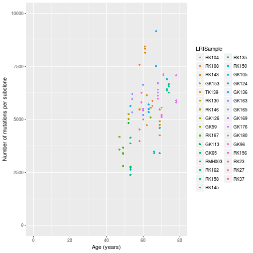

```r
# Read in patient data
pt.df <- read.table("../../data/summary/patient_summary.txt", sep="\t", header=TRUE, stringsAsFactors = FALSE)
pt.df <- pt.df[pt.df$include == "yes",]

# Read in phylogenetic trees
branch.df <- data.frame(Sample=character(0), Name=character(0), Num.clonal=integer(0), Num.mutations=integer(0))

branch.files <- system("ls params/Tree_structures/*optima*", intern = TRUE)
branch.files <- branch.files[substring(branch.files, first = 24, last = 30) %in% pt.df$sanger.ID]
branch.files <- branch.files[!(substring(branch.files, first = 24, last = 30) %in% c("PD24238", "PD24242"))]
# This previous line removes a patient for which only one sample gave good sequence; and a tumour with two completely independent clones (ie two separate cancers)

for (i in branch.files)
{
  temp <- suppressWarnings(read.table(i, header=TRUE, sep="\t", stringsAsFactors = FALSE))
  sample <- substring(i, 24, 30)
  lri.sample <- pt.df[pt.df$"sanger.ID"==sample,2]

  temp.term <- data.frame(Sample = rep(sample, sum(temp$Terminal == "Yes")),
                          LRISample = rep(lri.sample, sum(temp$Terminal == "Yes")),
                          Name = temp$Name[temp$Terminal == "Yes"],
                          Num.clonal = rep(temp$no.of.mutations.assigned[temp$Name=="T"], sum(temp$Terminal=="Yes")),
                          Num.mutations = rep(0, sum(temp$Terminal == "Yes")),
                          Age = rep(pt.df$Age[pt.df$sanger.ID == sample], sum(temp$Terminal == "Yes")))

  # This next loop calculates the number of mutations from root of phylogenetic tree to tip of each terminal branch
  for (j in temp.term$Name)
  {
    constituents <- unlist(strsplit(j, ">"))
    for (k in 2:length(constituents)) {constituents[k] <- paste(constituents[k-1], constituents[k], sep=">")}
    temp.term$Num.mutations[temp.term$Name == j] <- sum(temp$no.of.mutations.assigned[temp$Name %in% constituents])
  }
  branch.df <- rbind(branch.df, temp.term)
}

# Now plot the relationship between number of mutations on each branch and age
ggplot(data = branch.df, aes(x=Age, y=Num.mutations, color=LRISample)) +
  geom_point(shape=16) +
  xlim(c(0,80)) + ylim(c(0,10000)) +
  xlab("Age (years)") + ylab("Number of mutations per subclone")
```

## Fit linear mixed effects models to estimate mutation rate per year

To enable the estimation of the mutation rate per year (and check whether the fit is statistically significant), we fit linear mixed effects (LME) models. This is required because of course the different subclones (branches of the phylogenetic tree) within each patient are not independent (they share at least part of their ancestry). The LME models allow us to manage this within-patient correlation in a statistically appropriate framework. We will also be able to generate estimates of the mutation rate per year for each patient specifically, estimates that represent a compromise between the observed rate for each patient and the population average.

```r
# Test fits with and without intercepts

muts.per.year.lmer.with.pt.intercepts <- lmer(Num.mutations ~ Age + (Age | Sample), data=branch.df, REML=FALSE)
muts.per.year.lmer.with.pop.intercept <- lmer(Num.mutations ~ Age -1 + (Age | Sample), data=branch.df, REML=FALSE)
muts.per.year.lmer <- lmer(Num.mutations ~ Age - 1 + (Age - 1 | Sample), data=branch.df, REML=FALSE)

kable(anova(muts.per.year.lmer, muts.per.year.lmer.with.pop.intercept, muts.per.year.lmer.with.pt.intercepts))
```

|  | Df | AIC | BIC | logLik | deviance | Chisq | Chi Df | Pr(>Chisq) |
| --- | --- | --- | --- | --- | --- | --- | --- | --- |
| muts.per.year.lmer | 3 | 1241.274 | 1248.187 | -617.6372 | 1235.274 | NA | NA | NA |
| muts.per.year.lmer.with.pop.intercept | 5 | 1245.138 | 1256.659 | -617.5692 | 1235.138 | 0.1360513 | 2 | 0.9342365 |
| muts.per.year.lmer.with.pt.intercepts | 6 | 1247.080 | 1260.905 | -617.5401 | 1235.080 | 0.0580850 | 1 | 0.8095487 |

```r
# Print summary of model without intercepts
print(summary(muts.per.year.lmer))
```

Linear mixed model fit by maximum likelihood ['lmerMod'] Formula: Num.mutations ~ Age - 1 + (Age - 1 | Sample) Data: branch.df

```
 AIC      BIC   logLik deviance df.resid
```

1241.3 1248.2 -617.6 1235.3 71

Scaled residuals: Min 1Q Median 3Q Max -2.2853 -0.4185 0.0333 0.3143 3.1838

Random effects: Groups Name Variance Std.Dev. Sample Age 266.9 16.34  
Residual 504921.4 710.58  
Number of obs: 74, groups: Sample, 31

Fixed effects: Estimate Std. Error t value Age 87.213 3.261 26.75

```r
 # Generate the bootstrap dataset for this LME
 mySumm.muts.per.yr <- function(.) {
   unlist(fixef(.) + ranef(.)$Sample[,1])
 }

 boot2 <- bootMer(muts.per.year.lmer, mySumm.muts.per.yr, nsim=1000, use.u=TRUE, type="parametric")
 colnames(boot2$t) <- row.names(ranef(muts.per.year.lmer)$Sample)
```

Thus, there is no evidence that including intercepts helps the fit of the model.

## Fit linear mixed effects models to estimate age at which landmark events occur

### Most recent common ancestor (MRCA)

We now fit linear mixed effects models to estimate age from the number of mutations. This will then be used to provide estimates of the age at which key landmark events occur, such as emergence of the most recent common ancestor (MRCA) and copy number gains (especially the t(3;5) events).

The method is to fit the LME, and then use the patient-specific estimates of the slope to time the events from the observed number of mutations that have accumulated by the time that event occurs in that patient. For timing the MRCA, this is simply the number of mutations that are fully clonal, as estimated by the Hierarchical Dirichlet process. For timing the t(3;5) event and other copy number gains that are fully clonal, this can be approached in two ways. Firstly, it can be expressed as a fraction of time between 0 and emergence of MRCA through the fraction of mutations that are duplicated versus clonal but present on only a single copy of the duplicated chromosome (see [Nik-Zainal et al, Cell 2012; 149(5): 994-1007](http://www.cell.com/cell/abstract/S0092-8674%2812%2900527-2) for more details). Secondly, we can estimate directly from the number of mutations present pre-duplication, assuming we know what fraction of the genome has sufficient coverage for calling events.

Parametric boot-strapping is used to generate 95% confidence intervals for the timing estimates.

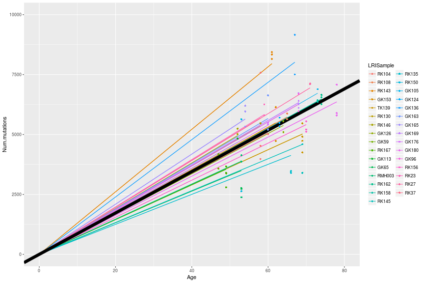

```r
branch.df$Scaled.num.muts <- scale(branch.df$Num.mutations, center=FALSE)
scale.factor <- attr(branch.df$Scaled.num.muts, which = "scaled:scale")

age.lmer <- lmer(Age ~ Scaled.num.muts - 1 + (Scaled.num.muts - 1 | Sample), data=branch.df)
branch.df$Pt.fitted.num.muts <- scale.factor / (ranef(age.lmer)$Sample[branch.df$Sample,] + fixef(age.lmer)["Scaled.num.muts"]) * branch.df$Age

# Visual check of model's fit
ggplot(data = branch.df, aes(x=Age, y=Num.mutations, color=LRISample)) +
  geom_segment(aes(x=0, y = 0, xend=Age, yend=Pt.fitted.num.muts, colour=LRISample), data=branch.df) +
  geom_abline(intercept=0,slope=scale.factor / fixef(age.lmer), size=3) +
  geom_point(shape=16) +
  xlim(c(0,80)) + ylim(c(0,10000))
```

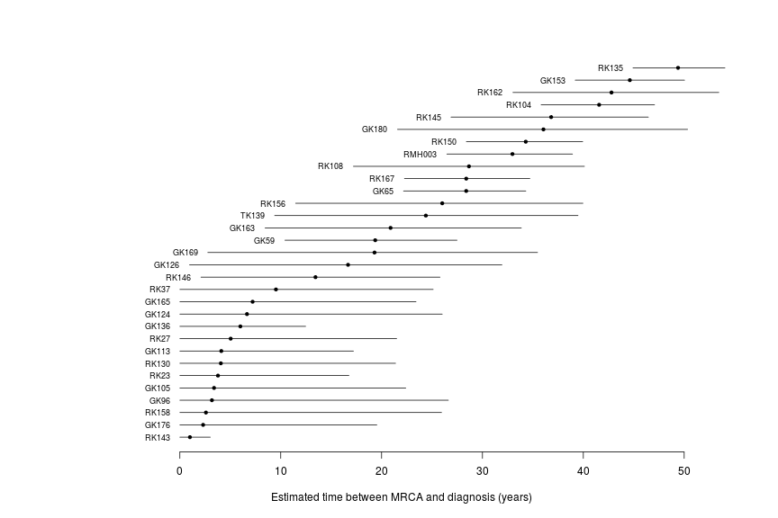

```r
# Generate point estimates for the timing of the MRCA emergence
new.dat <- data.frame(Sample=branch.df$Sample, LRISample=branch.df$LRISample, Scaled.num.muts=branch.df$Num.clonal / scale.factor, Age=branch.df$Age)
new.dat <- new.dat[!duplicated(new.dat$Sample),]
new.dat$MRCA.pred.age <- predict(age.lmer, newdata = new.dat)

# Now generate 95% CIs on the predictions for MRCA timing
# Note that CIs for lme models are challenging - bootstrapping appears to be most robust

mySumm <- function(.) {
  predict(., newdata=new.dat, re.form=NULL)
}

####Collapse bootstrap into median, 95% PI
sumBoot <- function(merBoot) {
  return(
    data.frame(fit = apply(merBoot$t, 2, function(x) as.numeric(quantile(x, probs=.5, na.rm=TRUE))),
               lwr = apply(merBoot$t, 2, function(x) as.numeric(quantile(x, probs=.025, na.rm=TRUE))),
               upr = apply(merBoot$t, 2, function(x) as.numeric(quantile(x, probs=.975, na.rm=TRUE)))
    )
  )
}

boot1 <- bootMer(age.lmer, mySumm, nsim=1000, use.u=FALSE, type="parametric")

PI.boot1 <- sumBoot(boot1)
PI.boot1$Age <- new.dat$Age
PI.boot1$pred.fit <- new.dat$MRCA.pred.age
PI.boot1$Time.lag <- PI.boot1$Age - PI.boot1$fit
PI.boot1$Time.lag[PI.boot1$Time.lag < 0] <- PI.boot1$Age[PI.boot1$Time.lag < 0] - PI.boot1$pred.fit[PI.boot1$Time.lag < 0]
PI.boot1$lag.lwr <- PI.boot1$Age - PI.boot1$upr
PI.boot1$lag.lwr[PI.boot1$lag.lwr < 0] <- 0
PI.boot1$lag.upr <- PI.boot1$Age - PI.boot1$lwr
PI.boot1$ID <- new.dat$Sample
PI.boot1$LRIID <- new.dat$LRISample
PI.boot1 <- PI.boot1[order(PI.boot1$Time.lag),]

plot(PI.boot1$Time.lag, 1:nrow(PI.boot1), pch=20, xlim=c(-10,max(PI.boot1$lag.upr)), axes=FALSE, xlab="Estimated time between MRCA and diagnosis (years)", ylab="")
segments(x0 = PI.boot1$lag.lwr, x1 = PI.boot1$lag.upr, y0 = 1:nrow(PI.boot1))
axis(side=1, at=(0:5)*10, labels=(0:5)*10)
text(x = PI.boot1$lag.lwr-1, y = 1:nrow(PI.boot1), labels = PI.boot1$LRIID, adj = 1, cex=0.75)
```

### Age of occurrence of t(3;5) events with chr5q gains

To explore the data, we extract the somatically acquired base substitutions in the region of chromosome 5q that is duplicated. The variant allele fraction for each mutation called in any sample is extracted and then converted to a cancer cell fraction (CCF; the fraction of cancer cells in the sample that carry the mutation) using the level of normal cell contamination and copy number at that position. From this, we calculate whether the mutation was acquired prior to the duplication of chromosome 5q (if it was, the CCF will be close to 2; if not, CCF ~= 1). For clonal mutations (seen in all samples), we take the consensus across all samples to vote whether it more likely occurred before or after chr 5q duplication. Results are then plotted for each sample to allow assessment of consistency of the calls / data. This component is encoded in the function timing() in the code chunk below.

Then, we apply two similar methods to estimate the age of occurrence of the t(3;5) gain:

(1) The first is to use the number of chr 5q mutations that are clonal and acquired before the 5q duplication relative to the number that are clonal but acquired after duplication (correcting for the fact that post-duplication there is an extra copy of 5q and hence the mutation burden accumulates more quickly). The fraction of clonal time at which the duplication occurred is then estimated from the estimate of when the MRCA emerged. Bootstrapping provides 95% confidence intervals, incorporating the uncertainty in the numbers of pre- and post-duplication mutations and the age the MRCA emerges (and therefore mutation rate). This estimation is encoded in the function triploid.2.1.with.mrca.est() in the code chunk below.

(2) The second method is to derive the age of occurrence directly from the mutation rate estimated per patient from the LME and the number of mutations that have accumulated before the 5q was duplicated. This requires correction for the size of the region gained and what the total size of the genome that could have had mutations called (from the BAM files, we estimate that this is 5.32Gb for a typical sample in this series). Again, bootstrapping provides 95% confidence intervals, incorporating the uncertainty in the numbers of pre-duplication mutations and the patient-specific mutation rate. This method is encoded in the function triploid.direct.est() in the code chunk below.

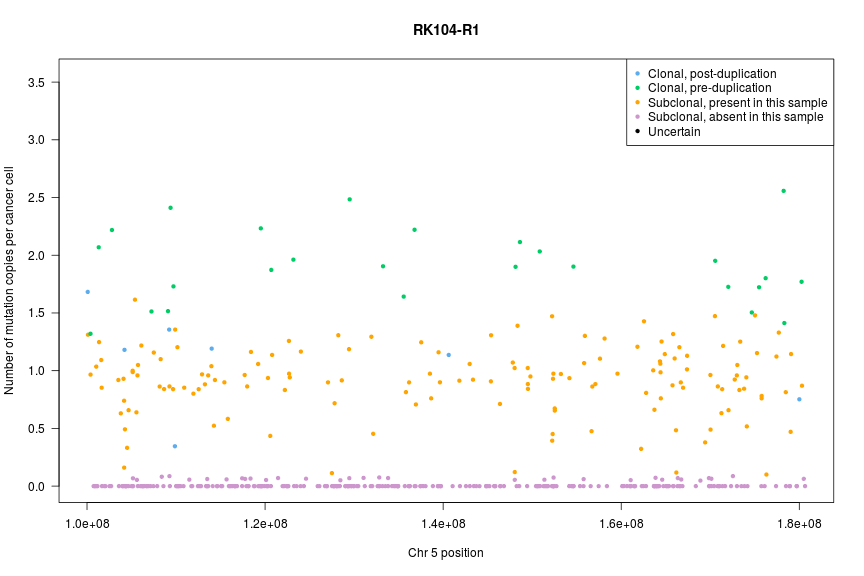

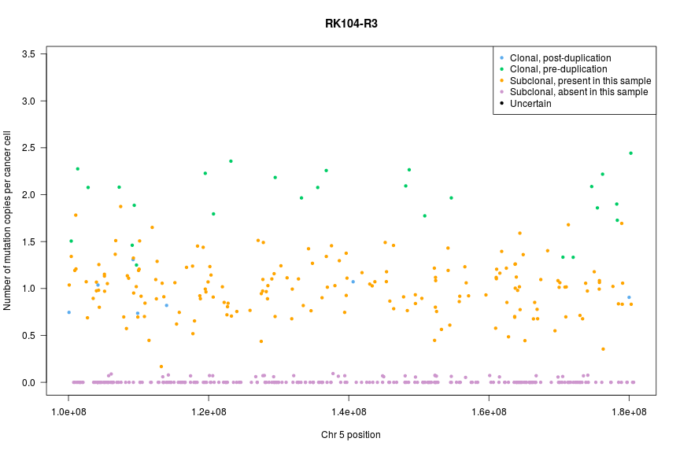

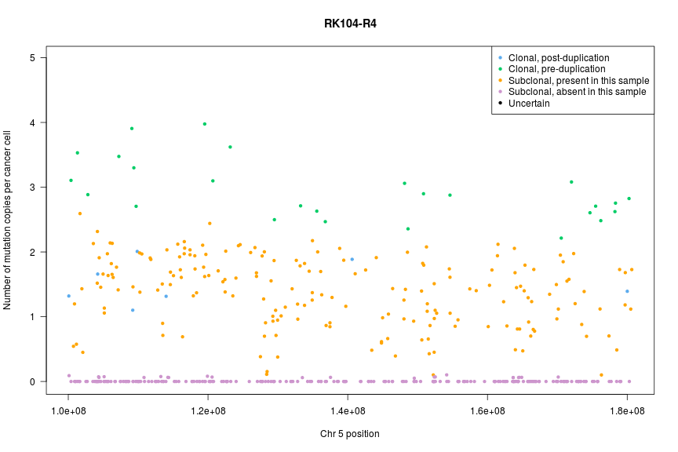

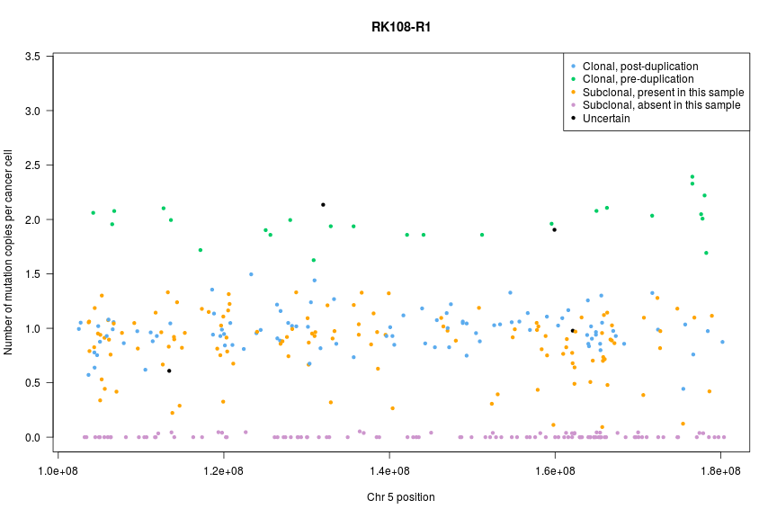

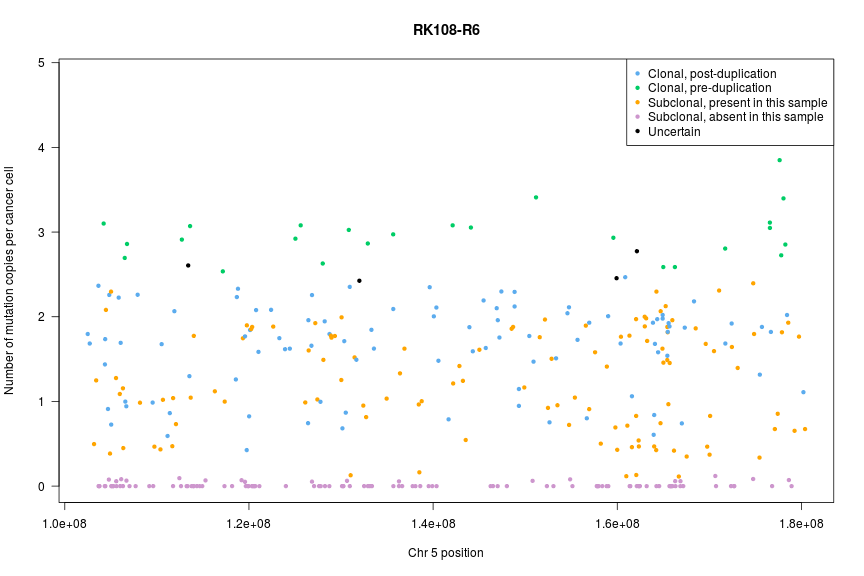

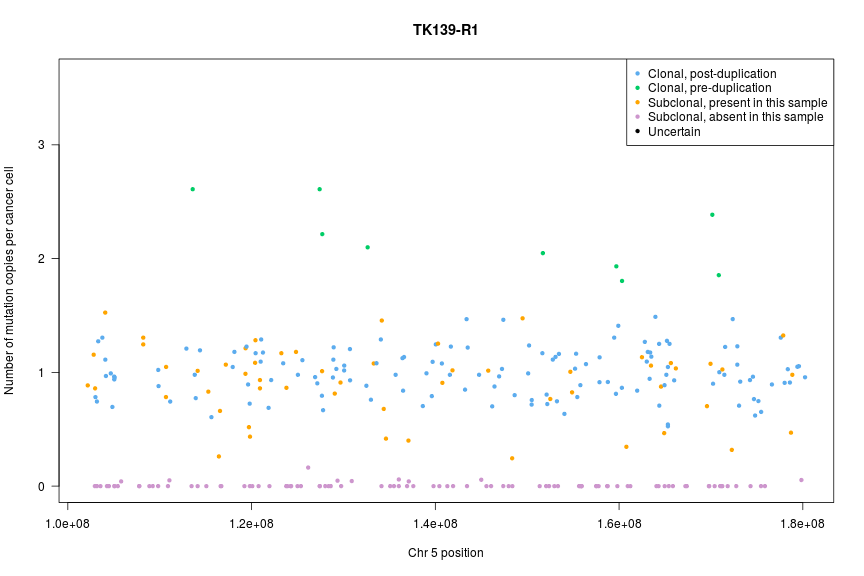

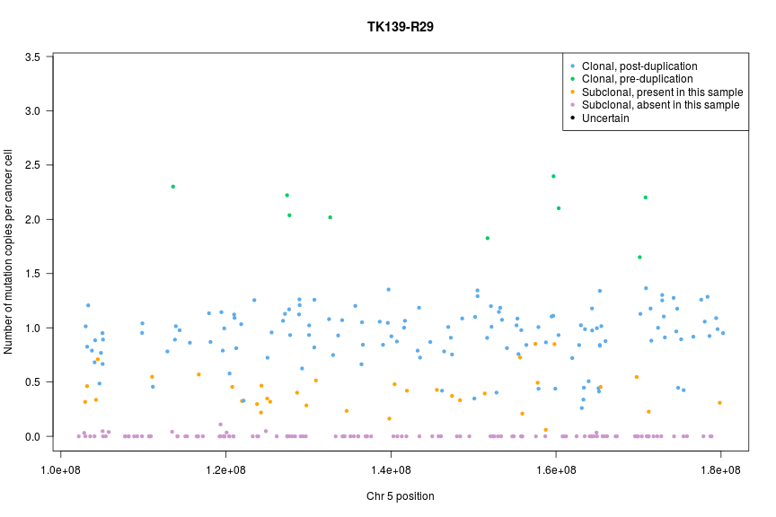

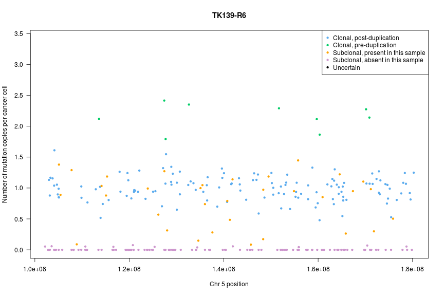

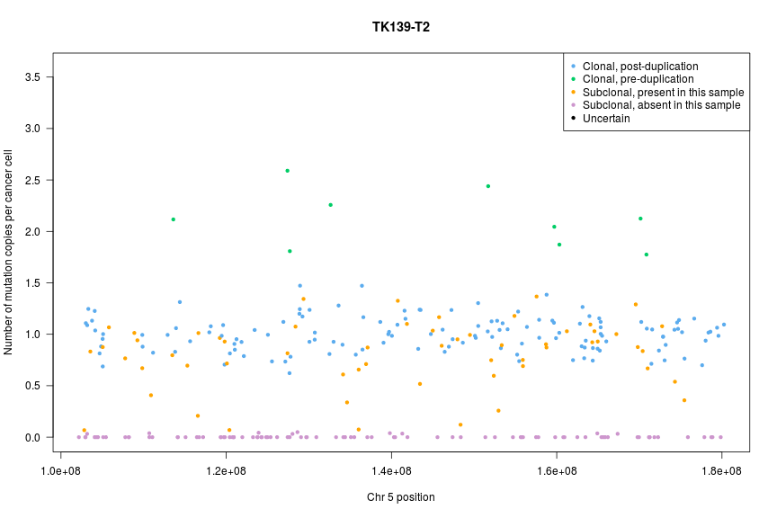

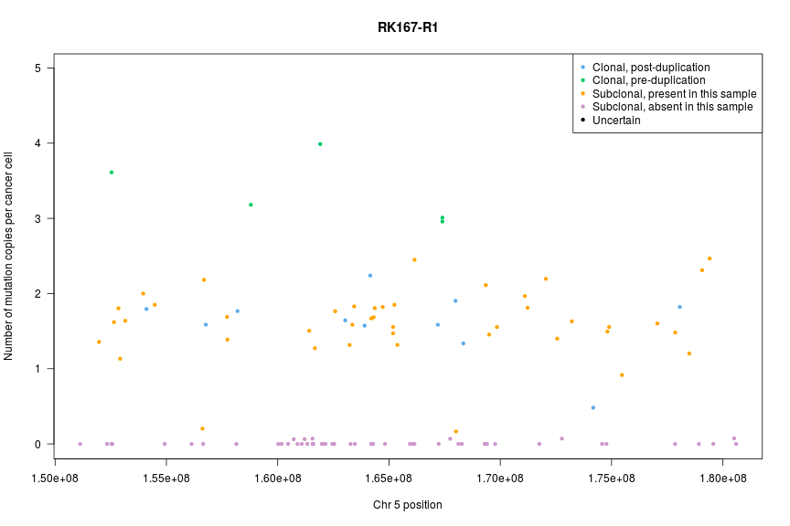

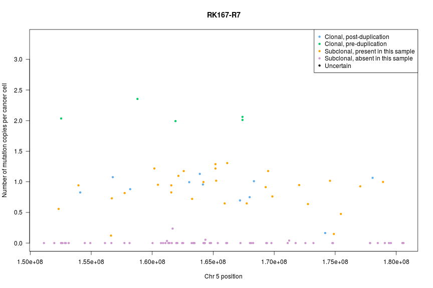

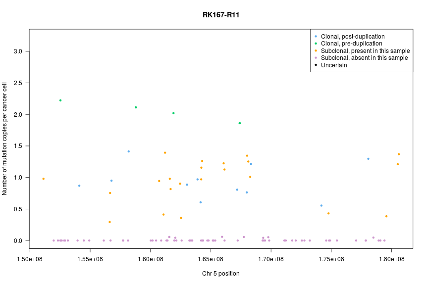

[26 more figures not shown]

```r
# First we define a function that reads in the relevant mutations and decides whether a variant is clonal or subclonal; and if clonal whether it occurs pre- or post-duplication

sa.df <- read.table("../../data/summary/sample_summary.txt", sep="\t", header=TRUE, stringsAsFactors = FALSE)
sa.df <- sa.df[sa.df$include == "yes",]

timing <- function(pt = "PD24236", sample.suffixes = c("a", "c", "d", "e"), normal.contam, chr, lower, upper)
{
  cn <- list()

  # Read in the mutation data for that patient
  file.name <- system(paste("ls ../../data/patient_data/merged/", pt, "/1152_*_consolidated_snp.tsv", sep=""), intern=TRUE)
  header.line.num <- system(paste("grep -n VariantID ../../data/patient_data/merged/", pt, "/1152_*_consolidated_snp.tsv", sep=""), intern=TRUE)
  header.line.num <- as.double(strsplit(header.line.num[2], split = ":")[[1]][1])
  muts <- read.table(file.name, header=TRUE, blank.lines.skip = TRUE, stringsAsFactors = FALSE, sep="\t", comment.char="#", row.names=NULL, skip=header.line.num-1)
  muts <- muts[muts$Chrom == chr & muts$Pos >= lower & muts$Pos <= upper,]

  # For each sample in that patient, calculate VAF and get CN at each mutated base-pair
  for (j in 1:length(sample.suffixes))
  {
    k <- sample.suffixes[j]
    muts[,paste(k,"VAF",sep="_")] <- muts[,paste(pt, k, "_MTR", sep="")] / muts[,paste(pt, k, "_DEP", sep="")]

    # Get CN file for that patient
    cn.file <- system(paste("ls ../../data/sample_data/BB_output/", pt, k, "*subclones.txt", sep=""), intern=TRUE)
    cn <- read.table(cn.file, header=TRUE, sep="\t", stringsAsFactors = FALSE)

    # Get total and minor copy number estimates for each base in the mutations file where the region shows no or minimal (<20%) subclonal CN variation
    muts[, paste(k,"T.Minor.CN",sep="_")]   <- sapply(1:nrow(muts), function(i,x,y) {
            temp.CN <- y$nMin1_A[y$chr == x$Chrom[i] & y$startpos <= x$Pos[i] & y$endpos >= x$Pos[i] & y$frac1_A > 0.8];
            if (length(temp.CN)>0) {return(temp.CN[1])} else {return(NA)}},
            x=muts, y=cn)
    muts <- muts[!is.na(muts[,paste(k,"T.Minor.CN",sep="_")]),]
    muts[, paste(k,"T.Total.CN",sep="_")] <- muts[,paste(k,"T.Minor.CN",sep="_")] + sapply(1:nrow(muts), function(i,x,y) {
            temp.CN <- y$nMaj1_A[y$chr == x$Chrom[i] & y$startpos <= x$Pos[i] & y$endpos >= x$Pos[i] & y$frac1_A > 0.8];
            if (length(temp.CN)>0) {return(temp.CN[1])} else {return(NA)}},
            x=muts, y=cn)

    # Calculate the CCF (fraction of cancer cells carrying mutation) from VAF and sample-specific normal cell contamination fraction
    muts[,paste(k,"CCF",sep="_")] <- muts[,paste(k,"VAF",sep="_")] * ((1-normal.contam[j]) * muts[,paste(k,"T.Total.CN",sep="_")] + normal.contam[j] * 2) / (1-normal.contam[j])

    # From CCF, infer whether mutation occurred pre- or post-duplication in that sample
    muts[,paste(k,"Status",sep="_")] <- rep("Uninformative", nrow(muts))
    muts[muts[,paste(k,"T.Total.CN",sep="_")] >= 2 & muts[,paste(k,"T.Minor.CN",sep="_")] == 0 & muts[,paste(k,"CCF",sep="_")] > 1.5, paste(k,"Status",sep="_")] <- "Preduplication"
    muts[muts[,paste(k,"T.Total.CN",sep="_")] >= 2 & muts[,paste(k,"T.Minor.CN",sep="_")] == 0 & muts[,paste(k,"CCF",sep="_")] <= 1.5, paste(k,"Status",sep="_")] <- "Post-duplication"
    muts[muts[,paste(k,"T.Total.CN",sep="_")] == 3 & muts[,paste(k,"T.Minor.CN",sep="_")] == 1 & muts[,paste(k,"CCF",sep="_")] > 1.5, paste(k,"Status",sep="_")] <- "Preduplication"
    muts[muts[,paste(k,"T.Total.CN",sep="_")] == 3 & muts[,paste(k,"T.Minor.CN",sep="_")] == 1 & muts[,paste(k,"CCF",sep="_")] <= 1.5, paste(k,"Status",sep="_")] <- "Post-duplication"
    muts[muts[,paste(k,"T.Total.CN",sep="_")] == 6 & muts[,paste(k,"T.Minor.CN",sep="_")] == 2 & muts[,paste(k,"CCF",sep="_")] > 2.5, paste(k,"Status",sep="_")] <- "Preduplication"
    muts[muts[,paste(k,"T.Total.CN",sep="_")] == 6 & muts[,paste(k,"T.Minor.CN",sep="_")] == 2 & muts[,paste(k,"CCF",sep="_")] <= 2.5, paste(k,"Status",sep="_")] <- "Post-duplication"
    muts[muts[,paste(k,"T.Total.CN",sep="_")] == 5 & muts[,paste(k,"T.Minor.CN",sep="_")] == 2 & muts[,paste(k,"CCF",sep="_")] > 2.5, paste(k,"Status",sep="_")] <- "Preduplication"
    muts[muts[,paste(k,"T.Total.CN",sep="_")] == 5 & muts[,paste(k,"T.Minor.CN",sep="_")] == 2 & muts[,paste(k,"CCF",sep="_")] <= 2.5, paste(k,"Status",sep="_")] <- "Post-duplication"
    muts[muts[,paste(k,"T.Total.CN",sep="_")] >= 4 & muts[,paste(k,"T.Minor.CN",sep="_")] == 1 & muts[,paste(k,"CCF",sep="_")] > 1.5, paste(k,"Status",sep="_")] <- "Preduplication"
    muts[muts[,paste(k,"T.Total.CN",sep="_")] >= 4 & muts[,paste(k,"T.Minor.CN",sep="_")] == 1 & muts[,paste(k,"CCF",sep="_")] <= 1.5, paste(k,"Status",sep="_")] <- "Post-duplication"

  }

  # Now, from all statuses across different samples, get a consensus status
  # First, read in the branch assignments of all mutations
  tree.file <- system(paste("ls params/Tree_structures/", pt, "*optima*", sep=""), intern = TRUE)
  tree.struct <- read.table(file=tree.file, header=TRUE, stringsAsFactors = FALSE, sep="\t")
  branch.assign <- read.table(paste("../../data/patient_data/clusters/", pt, "/", pt, "_assigned_mutations.txt", sep=""), header=TRUE, sep="\t", stringsAsFactors = FALSE)
  branch.assign <- branch.assign[branch.assign$chr == chr & branch.assign$pos >= lower & branch.assign$pos <= upper,]

  muts <- muts[muts$Pos %in% branch.assign$pos,]
  muts$Branch <- sapply(muts$Pos, function(i,x) {x$cluster[x$pos == i]}, x=branch.assign)

  # Identify clonal mutations (assigned to trunk of phylogenetic tree & >1 read reporting variant in all samples)
  muts$Timing <- rep("Subclonal", nrow(muts))
  muts$Timing[muts$Branch %in% (1:nrow(tree.struct))[tree.struct$Name == "T"] &
              sapply(1:nrow(muts), function(i,x,pt.name,samps) {all(x[i,paste(pt.name, samps, "_MTR", sep="")] > 1)}, x=muts, pt.name=pt, samps=sample.suffixes)] <- "Uncertain"
  muts$Timing[sapply(1:nrow(muts), function(i,x) {sum(x[i,grepl("_Status", names(x))] == "Preduplication") > length(sample.suffixes)/2 & x$Timing[i] == "Uncertain"}, x=muts)] <- "Clonal Preduplication"
  muts$Timing[sapply(1:nrow(muts), function(i,x) {sum(x[i,grepl("_Status", names(x))] == "Post-duplication") > length(sample.suffixes)/2 & x$Timing[i] == "Uncertain"}, x=muts)] <- "Clonal Post-duplication"

  # Generate plot of CCF per sample
  for (i in sample.suffixes)
  {
    point.col <- as.character(factor(muts$Timing, levels=c("Clonal Post-duplication", "Clonal Preduplication", "Subclonal", "Uncertain"), labels=c("steelblue2", "springgreen3", "plum3", "black")))
    point.col[muts[,paste(pt, i, "_MTR", sep="")] > 1 & muts$Timing == "Subclonal"] <- "orange"
    plot(muts$Pos, muts[,paste(i, "CCF", sep="_")], pch=20, col=point.col, xlab=paste("Chr", chr, "position"), ylab="Number of mutation copies per cancer cell", las=1, ylim=c(0,max(muts[,paste(i, "CCF", sep="_")])+1))
    legend("topright", pch=20, col=c("steelblue2", "springgreen3", "orange", "plum3", "black"), legend=c("Clonal, post-duplication", "Clonal, pre-duplication", "Subclonal, present in this sample", "Subclonal, absent in this sample", "Uncertain"))
    sanger.sid <- paste(pt, i, sep="")
    lri.sid <- sa.df[sa.df$"sanger.ID"==sanger.sid,2]
    title(main = lri.sid)
  }

  return(muts)
}

  # The first method of calculating timing uses MRCA estimates and fraction of mutations at ploidy 1 and ploidy 2 to estimate length
 triploid.2.1.with.mrca.est <- function(ploidy.1, ploidy.2, bs, ID, age)
 {
   # bs is bootstrap output from LME
   point.est <- ploidy.2 / (ploidy.2 + (ploidy.1 - ploidy.2)/3)
   iter <- bs$R
   total.muts <- ploidy.1 + ploidy.2
   prob.2 <- ploidy.2 / total.muts

   resamps <- rbinom(n=iter, size=total.muts, p=prob.2)
   ests.bs <- resamps / (resamps + (total.muts - 2*resamps)/3)
   ests.bs[ests.bs > 1] <- 1

   age.mrca.bs <- bs$t[,ID]
   age.mrca.bs[age.mrca.bs > age] <- age

   ests.bs <- ests.bs * age.mrca.bs

   return(quantile(ests.bs, c(0.5,0.025,0.975)))
 }


 # The second method estimates the timing directly from the estimated mutation rate and number of mutations acquired before duplication
  triploid.direct.est <- function(ploidy.2, bs, ID, dup.region.size.in.Gb, callable.genome.size=5.32)
 {
   # bs is bootstrap output from above
   iter <- bs$R
   mut.rate.bs <- bs$t[,ID] / callable.genome.size
   resamps <- rpois(n=iter, lambda = ploidy.2)
   ests.bs <- resamps / dup.region.size.in.Gb / mut.rate.bs

   return(quantile(ests.bs, c(0.5,0.025,0.975)))
 }


 # Set up the data-frame for the results
 tloc.ids = c("PD21872", "PD21874", "PD21877", "PD23583", "PD23585", "PD24231", "PD24232", "PD24234", "PD24235", "PD24236", "PD24237", "PD24239")
 tloc.ids.len <- length(tloc.ids)

 lri.ids <- rep("", tloc.ids.len)
 for (x in 1:tloc.ids.len) {
  lri.ids[x] <- pt.df[pt.df$"sanger.ID"==tloc.ids[x],2]
 }

 t3_5.abs.time <- data.frame(ID = tloc.ids, triploid.lwr = rep(0, tloc.ids.len), triploid.est = rep(0, tloc.ids.len), triploid.upr = rep(0, tloc.ids.len), stringsAsFactors = FALSE)
 row.names(PI.boot1) <- PI.boot1$ID
 t3_5.abs.time$Age <- PI.boot1[t3_5.abs.time$ID, "Age"]
 t3_5.abs.time$MRCA.est <- PI.boot1[t3_5.abs.time$ID, "Age"] - PI.boot1[t3_5.abs.time$ID, "Time.lag"]
 colnames(boot1$t) <- new.dat$Sample
 t3_5.abs.time$Est.mut.rate.per.Gb.per.year <- (fixef(muts.per.year.lmer) + ranef(muts.per.year.lmer)$Sample[t3_5.abs.time$ID,"Age"]) / 6
 t3_5.abs.time$alt.trip.upr <- t3_5.abs.time$alt.trip.est <- t3_5.abs.time$alt.trip.lwr <- rep(0,tloc.ids.len)
 t3_5.abs.time$LRIID <- lri.ids
 row.names(t3_5.abs.time) <- t3_5.abs.time$ID

 # Run the patients through the functions in turn ([params/timing_inputs.csv](file:///params/timing_inputs.csv));
time.inputs <- read.table( "params/timing_inputs.csv", header=F, sep=",", stringsAsFactors=F, strip.white=T, as.is=T )

for (i in 1:nrow(time.inputs)) {
   branch.names <- unlist(strsplit(time.inputs[i,2],";"))
   branch.parms <- as.numeric(unlist(strsplit(time.inputs[i,3],";")))
   branches.pid <- time.inputs[i,1]     # patient ID
   branches.age <- time.inputs[i,8]     # patient age
   timing(branches.pid, branch.names, branch.parms, time.inputs[i,4], time.inputs[i,5], time.inputs[i,6]) -> a
   t3_5.abs.time[t3_5.abs.time$ID == branches.pid, c("triploid.est", "triploid.lwr", "triploid.upr")] <-
   triploid.2.1.with.mrca.est(ploidy.1 = table(a$Timing)["Clonal Post-duplication"],
                              ploidy.2 = table(a$Timing)["Clonal Preduplication"],
                              bs=boot1, ID=branches.pid, age=branches.age)
   t3_5.abs.time[branches.pid, c("alt.trip.est", "alt.trip.lwr", "alt.trip.upr")] <- triploid.direct.est(table(a$Timing)["Clonal Preduplication"], boot2, branches.pid, time.inputs[i,7]/1000)
}
```

```r
# Report the results
 # kable(t3_5.abs.time,row.names=FALSE)
 t3_5.abs.time.rep <- t3_5.abs.time
 row.names(t3_5.abs.time.rep) <- t3_5.abs.time$LRIID
 kable(t3_5.abs.time.rep)
```

|  | ID | triploid.lwr | triploid.est | triploid.upr | Age | MRCA.est | Est.mut.rate.per.Gb.per.year | alt.trip.lwr | alt.trip.est | alt.trip.upr | LRIID |
| --- | --- | --- | --- | --- | --- | --- | --- | --- | --- | --- | --- |
| RK104 | PD21872 | 10.938395 | 16.432742 | 22.185842 | 58 | 16.43274 | 15.26627 | 11.613700 | 18.527707 | 26.672249 | RK104 |
| RK108 | PD21874 | 10.739409 | 18.041202 | 26.175018 | 65 | 36.33812 | 14.72333 | 11.522629 | 18.917552 | 27.634223 | RK108 |
| TK139 | PD21877 | 2.898020 | 7.840651 | 14.074049 | 69 | 44.61501 | 11.94899 | 3.531652 | 8.062710 | 14.330546 | TK139 |
| RK167 | PD23583 | 5.548462 | 14.556855 | 23.527838 | 49 | 20.60705 | 11.80136 | 2.441123 | 11.249291 | 22.952977 | RK167 |
| GK65 | PD23585 | 4.067799 | 7.341303 | 11.915922 | 53 | 24.61008 | 10.12517 | 4.218487 | 8.594933 | 14.059000 | GK65 |
| GK163 | PD24231 | 6.127674 | 11.782681 | 18.789837 | 60 | 39.10981 | 15.60205 | 5.993376 | 10.911055 | 16.302242 | GK163 |
| GK165 | PD24232 | 2.903123 | 8.840734 | 17.234043 | 54 | 46.78683 | 17.38481 | 2.163165 | 6.561965 | 13.612118 | GK165 |
| GK176 | PD24234 | 0.000000 | 3.435768 | 9.364139 | 60 | 57.69398 | 15.02653 | 0.000000 | 2.916591 | 7.814361 | GK176 |
| GK180 | PD24235 | 11.133159 | 19.945748 | 30.953686 | 78 | 41.95394 | 13.48045 | 12.470850 | 20.426234 | 30.978560 | GK180 |
| GK96 | PD24236 | 16.635997 | 26.046465 | 34.535433 | 68 | 64.81986 | 15.35655 | 18.796737 | 27.920701 | 38.766939 | GK96 |
| RK156 | PD24237 | 9.708996 | 16.910246 | 25.641266 | 70 | 43.98573 | 12.82140 | 11.242602 | 19.223540 | 28.502538 | RK156 |
| RK23 | PD24239 | 9.598668 | 17.564885 | 25.652174 | 59 | 55.22055 | 16.50226 | 8.289134 | 16.062970 | 25.860163 | RK23 |

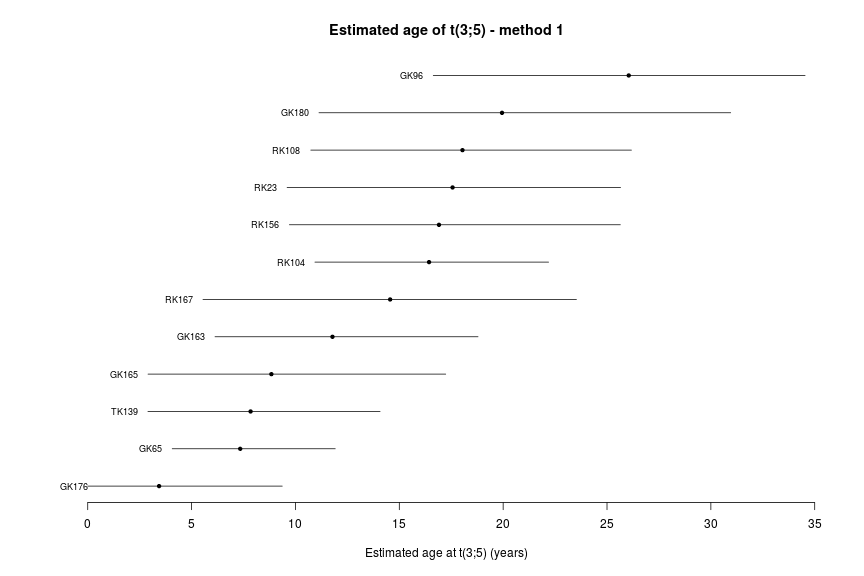

```r
 # Generate plot of estimated age of occurrence of t(3;5) - method 1
 t3_5.abs.time <- t3_5.abs.time[order(t3_5.abs.time$triploid.est),]
 plot(t3_5.abs.time$triploid.est, 1:nrow(t3_5.abs.time), pch=20, xlim=c(0,max(t3_5.abs.time$triploid.upr)), axes=FALSE, xlab="Estimated age at t(3;5) (years)", ylab="")
 segments(x0 = t3_5.abs.time$triploid.lwr, x1 = t3_5.abs.time$triploid.upr, y0 = 1:nrow(t3_5.abs.time))
 axis(side=1, at=(0:7)*5, labels=(0:7)*5)
 text.x.poss <- t3_5.abs.time$triploid.lwr-0.5
 text.x.poss[1] <- text.x.poss[1] + 0.5
 text(x = text.x.poss, y = 1:nrow(t3_5.abs.time), labels = t3_5.abs.time$LRIID, adj = 1, cex=0.75)
 title("Estimated age of t(3;5) - method 1")
```

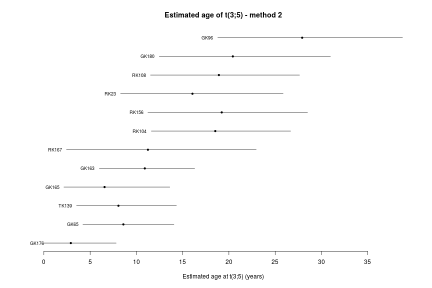

```r
  # Generate plot of estimated age of occurrence of t(3;5) - method 2
 plot(t3_5.abs.time$alt.trip.est, 1:nrow(t3_5.abs.time), pch=20, xlim=c(0,max(t3_5.abs.time$alt.trip.upr)), axes=FALSE, xlab="Estimated age at t(3;5) (years)", ylab="")
 segments(x0 = t3_5.abs.time$alt.trip.lwr, x1 = t3_5.abs.time$alt.trip.upr, y0 = 1:nrow(t3_5.abs.time))
 axis(side=1, at=(0:7)*5, labels=(0:7)*5)
 text.x.poss <- t3_5.abs.time$alt.trip.lwr-0.5
 text.x.poss[1] <- text.x.poss[1] + 0.5
 text(x = text.x.poss, y = 1:nrow(t3_5.abs.time), labels = t3_5.abs.time$LRIID, adj = 1, cex=0.75)
 title("Estimated age of t(3;5) - method 2")
```